# 고급회귀분석 5장

2025-03-18

## 5.1 모형의 변환

### (예 5.1)

```r
x = c(1,1,2,2,3,3,4,4,5,5) ; y = c(45,40,60,62,75,81,115,150,145,148) ; logy = log(y, base = 10)
```

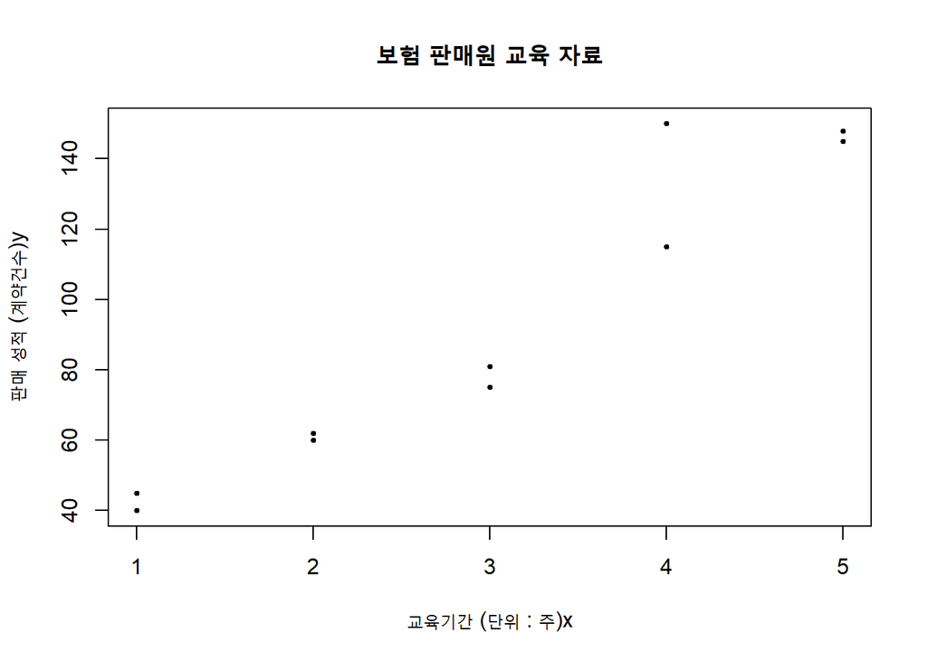

```
##
## Call:
## lm(formula = logy ~ x, data = X)
##
## Residuals:
##       Min        1Q    Median        3Q       Max
## -0.042717 -0.032720 -0.003986  0.012164  0.117365
##
## Coefficients:
##             Estimate Std. Error t value Pr(>|t|)
## (Intercept)  1.49493    0.03681   40.61 1.49e-10 ***
## x            0.14095    0.01110   12.70 1.39e-06 ***
## ---
## Signif. codes:  0 '***' 0.001 '**' 0.01 '*' 0.05 '.' 0.1 ' ' 1
##
## Residual standard error: 0.04964 on 8 degrees of freedom
## Multiple R-squared:  0.9527, Adjusted R-squared:  0.9468
## F-statistic: 161.3 on 1 and 8 DF,  p-value: 1.391e-06
```

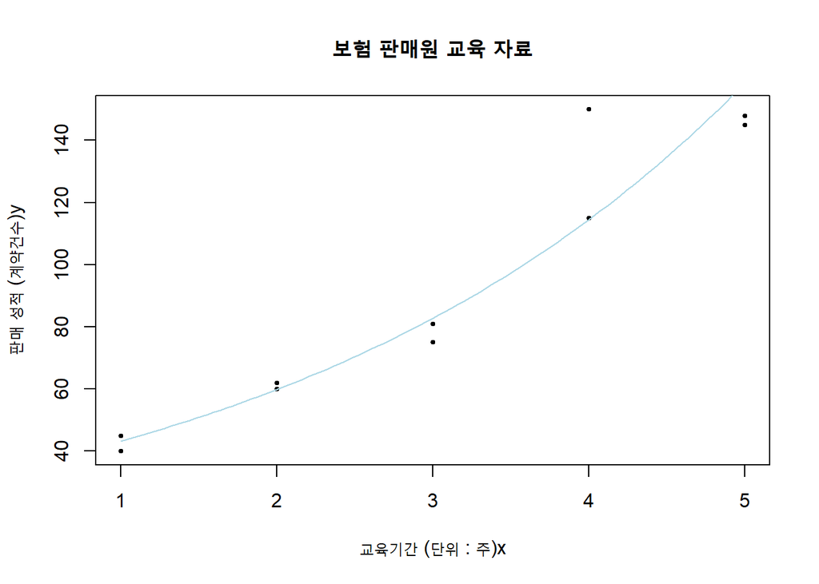

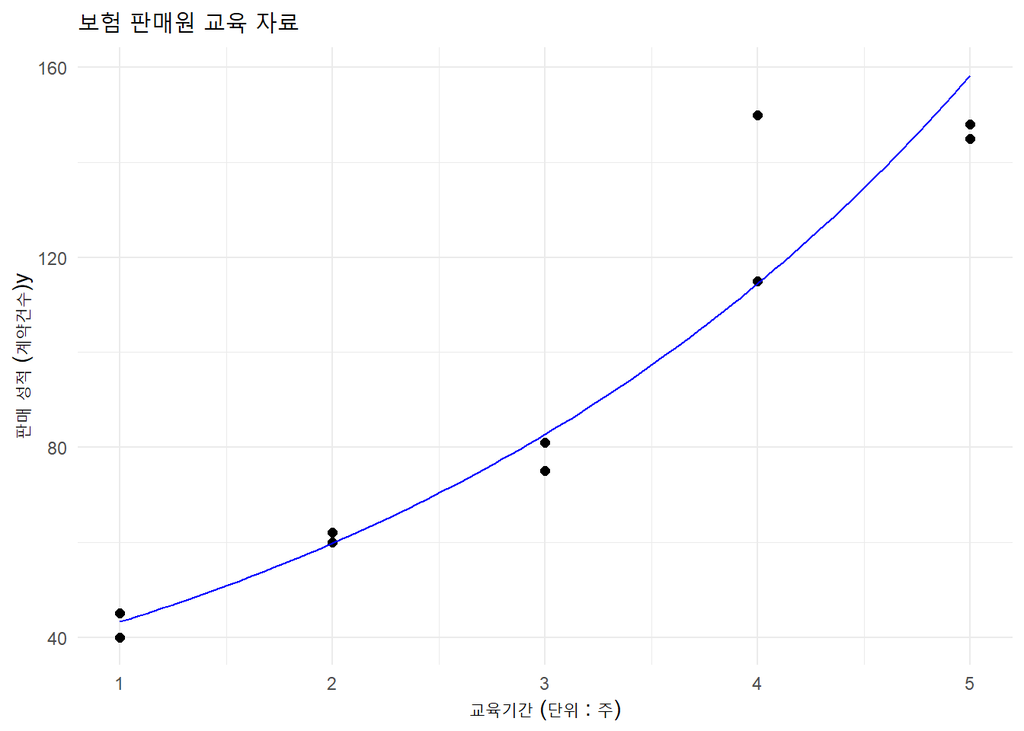

```r
beta_0_hat ; beta_1_hat
```

```
## (Intercept)
##    1.494934
```

```
##        x
## 0.140948
```

```r
alpha_0_hat ; alpha_1_hat
```

```
## (Intercept)
##    31.25604
```

```
##        x
## 1.383401
```

[figure not shown]

```r
plot(x,logy, xlab = "x", ylab = "logy",
     main = "변환된 회귀모형", pch = 19, cex = 0.5)

abline(coef = c(beta_0_hat, beta_1_hat), col = "lightblue")
```

```r
library(glue)
X_before = data.frame(x,y) ; X_after = data.frame(x,logy)
lm.fit_before = lm(y ~ x, data = X_before)
anova_before = anova(lm.fit_before)
SST_before = sum((y - mean(y))^{2}) ; SSE_before = anova_before$`Sum Sq`[2]

lm.fit_after = lm(logy ~ x, data = X_after)
anova_after = anova(lm.fit_after)
SST_after = sum((logy - mean(logy))^{2}) ; SSE_after = anova_after$`Sum Sq`[2]

R_sq_before =1 - SSE_before / SST_before ; R_sq_after =1 - SSE_after / SST_after

print(glue("R_sq_before = {R_sq_before}, R_sq_after = {R_sq_after}"))
```

```
## R_sq_before = 0.914494670732635, R_sq_after = 0.95273756527879
```

## 5.4 두 회귀선의 비교

### (예 5.2)

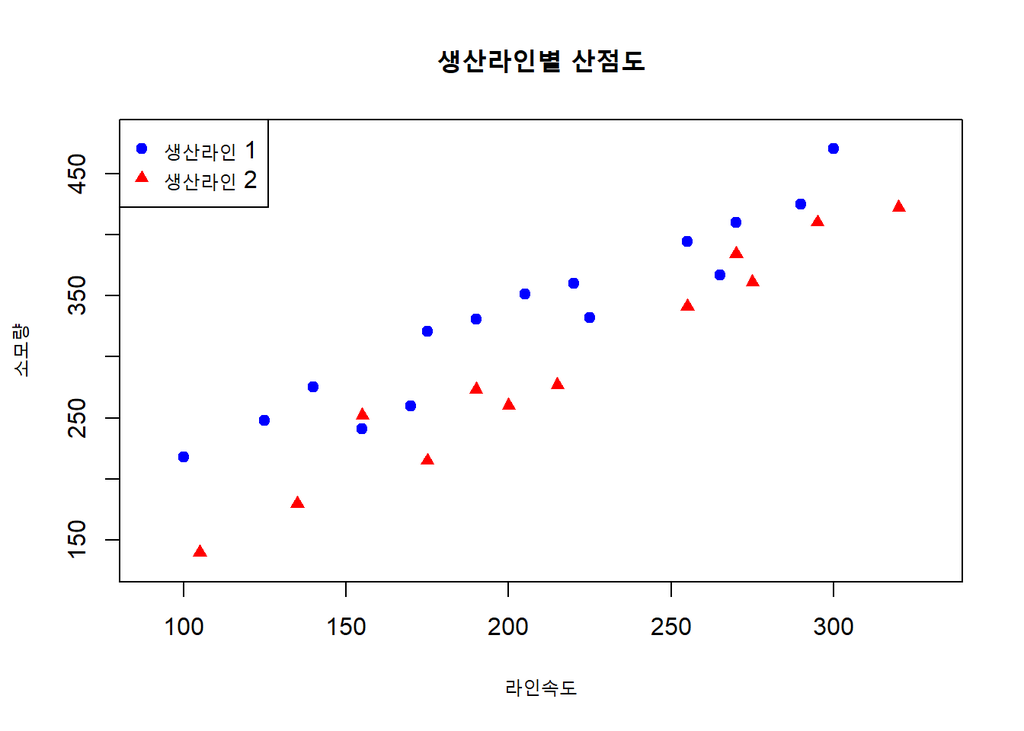

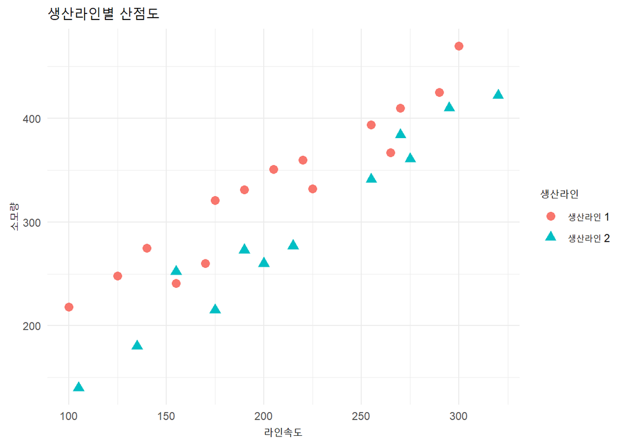

```r
x1 = c(100,125,220,205,300,255,225,175,270,170,155,190,140,290,265)
y1 = c(218,248,360,351,470,394,332,321,410,260,241,331,275,425,367)

x2 = c(105,215,270,255,175,135,200,275,155,320,190,295)
y2 = c(140,277,384,341,215,180,260,361,252,422,273,410)

## Full model

full_model.1 = lm(y1 ~ x1) ; full_model.2 = lm(y2 ~ x2)
anova.1 = anova(full_model.1) ; anova.2 = anova(full_model.2)

coef(full_model.1) ; coef(full_model.2)
```

```
## (Intercept)          x1
##   97.965328    1.145387
```

```
## (Intercept)          x2
##    7.574465    1.322049
```

```r
anova.1 ; anova.2
```

```
## Analysis of Variance Table
##
## Response: y1
##           Df Sum Sq Mean Sq F value    Pr(>F)
## x1         1  70441   70441  143.02 2.177e-08 ***
## Residuals 13   6403     493
## ---
## Signif. codes:  0 '***' 0.001 '**' 0.01 '*' 0.05 '.' 0.1 ' ' 1
```

```
## Analysis of Variance Table
##
## Response: y2
##           Df Sum Sq Mean Sq F value    Pr(>F)
## x2         1  87726   87726  250.55 2.083e-08 ***
## Residuals 10   3501     350
## ---
## Signif. codes:  0 '***' 0.001 '**' 0.01 '*' 0.05 '.' 0.1 ' ' 1
```

```r
SSE.1 = anova.1$`Sum Sq`[2] ; SSE.2 = anova.2$`Sum Sq`[2]
SSE.F = SSE.1 + SSE.2 ; df.F = anova.1$Df[2] + anova.2$Df[2]
```

```r
## Reduced model
X = c(x1, x2) ; Y = c(y1, y2)
reduced_model = lm(Y ~ X)
anova.reduced = anova(reduced_model)

coef(reduced_model)
```

```
## (Intercept)           X
##   64.035683    1.196306
```

```r
anova.reduced
```

```
## Analysis of Variance Table
##
## Response: Y
##           Df Sum Sq Mean Sq F value    Pr(>F)
## X          1 149661  149661  127.23 2.676e-11 ***
## Residuals 25  29408    1176
## ---
## Signif. codes:  0 '***' 0.001 '**' 0.01 '*' 0.05 '.' 0.1 ' ' 1
```

```r
SSE.R = anova.reduced$`Sum Sq`[2]
df.R = anova.reduced$Df[2]

F_0 = ((SSE.R - SSE.F) / (df.R - df.F)) / (SSE.F / df.F)
F_alpha = qf(0.05, df.R - df.F, df.F, lower.tail = FALSE)

print(glue("F_0 = {F_0}, F_alpha = {F_alpha}"))
```

```
## F_0 = 22.646534296706, F_alpha = 3.42213220786118
```

### (예 5.3)

```r
beta1.1_hat = coef(full_model.1)[2] ; beta1.2_hat = coef(full_model.2)[2]

MSE.F = SSE.F / (df.F) ; S_xx.1 = sum((x1 -mean(x1))^{2}) ; S_xx.2 = sum((x2 -mean(x2))^{2})

var_hat = MSE.F * ((1/S_xx.1) + (1/S_xx.2))

t_0 = (beta1.1_hat - beta1.2_hat) / sqrt(var_hat)
t_alpha = qt(0.025, df.F, lower.tail = FALSE)

print(glue("t_0 = {t_0}, t_alpha = {t_alpha}"))
```

```
## t_0 = -1.37119322803213, t_alpha = 2.06865761041905
```

## 5.9 R 실습

### 5.9.1 두 회귀모형의 검정

$\textbf{맥주생산라인의 문제}$ [표 5.2]의 각 생산라인에서 얻어진 표본자료의 모집단에 대하여 각 두 회귀직선모형

$$\begin{equation*}
y_{ij} = \beta_{0j} + \beta_{1j}x_{ij} + \epsilon_{ij} (i=1, \cdts,
n_j, ~~j= 1,2)
\end{equation*}$$

이 성립된다고 가정하고 (예 5.2)와 (예 5.3)을 실습을 통해 풀어 보기로 한다.

```r
# install.packages("gap")
library(gap)
x1 = c(100,125,220,205,300,255,225,175,270,170,155,190,140,290,265)
y1 = c(218,248,360,351,470,394,332,321,410,260,241,331,275,425,367)
lab1 = c(rep("a", length(x1)))

x2 = c(105,215,270,255,175,135,200,275,155,320,190,295)
y2 = c(140,277,384,341,215,180,260,361,252,422,273,410)
lab2 = c(rep("b", length(x2)))

tab5_2 = data.frame(c(x1, x2), c(y1, y2), c(lab1, lab2))
colnames(tab5_2) = c("x", "y", "lab")

head(tab5_2)
```

```
##     x   y lab
## 1 100 218   a
## 2 125 248   a
## 3 220 360   a
## 4 205 351   a
## 5 300 470   a
## 6 255 394   a
```

`chow.test()`를 사용하기 위해서는 먼저 각 생산라인별로 다음과 같이 설명변수와 반응변수를 생성한다.

```r
y1 <- tab5_2[which(tab5_2$lab == 'a'), 2]
y2 <- tab5_2[which(tab5_2$lab == 'b'), 2]
x1 <- tab5_2[which(tab5_2$lab == 'a'), 1]
x2 <- tab5_2[which(tab5_2$lab == 'b'), 1]
chow.test(y1, x1, y2, x2)
```

```
##      F value        d.f.1        d.f.2      P value
## 2.264653e+01 2.000000e+00 2.300000e+01 3.668926e-06
```

이 결과로부터 각 생산라인별 라인 속도에 대한 맥주의 평균 소모량에 관한 회귀식이 유의수준 $\alpha = 0.05$에서 동일하지 않음을 알 수 있다.

### 5.9.2 두 기울기의 검정

이제 (예 5.3)에서 살펴본 것처럼 기울기가 같은지 검정해 보기로 한다. 이를 위하여 서로 다른 두 자료 `data1`, `data2`에 대하여

$$\begin{equation*}
t_0 = \cfrac{\hat{\beta}_{11} -
\hat{\beta}_{12}}{\sqrt{\hat{\text{Var}} (\hat{\beta}_{11} -
\hat{\beta}_{12})}}
\end{equation*}$$

를 검정통계량으로 사용하는 유의수준 $\alpha$ 검정을 하기 위한 `slope_test(data1, data2, alpha)`함수를 작성하면 다음과 같다.

```r
slope_test = function(data1, data2, alpha){
  n_1 = dim(data1)[1] ; n_2 = dim(data2)[1]

  xbar_1 = mean(data1$x) ; ybar_1 = mean(data1$y)
  S_xx_1 = sum((data1$x - xbar_1)^{2})
  S_xy_1 = as.numeric(t(data1$x - xbar_1) %*% (data1$y - ybar_1))
  beta1_1 = S_xy_1 / S_xx_1
  beta0_1 = ybar_1 - beta1_1 * xbar_1
  yhat_1 = beta0_1 + beta1_1 * data1$x
  SSE_1 = sum((data1$y - yhat_1)^{2})

  xbar_2 = mean(data2$x) ; ybar_2 = mean(data2$y)
  S_xx_2 = sum((data2$x - xbar_2)^{2})
  S_xy_2 = as.numeric(t(data2$x - xbar_2) %*% (data2$y - ybar_2))
  beta1_2 = S_xy_2 / S_xx_2
  beta0_2 = ybar_2 - beta1_2 * xbar_2
  yhat_2 = beta0_2 + beta1_2 * data2$x
  SSE_2 = sum((data2$y - yhat_2)^{2})

  SSEF = SSE_1 + SSE_2
  df_SSEF = (n_1 - 2) + (n_2 - 2)
  MSEF = SSEF / df_SSEF

  t_0 = (beta1_1 - beta1_2) / sqrt(MSEF * (1/S_xx_1 + 1/S_xx_2))
  critical_value = qt(alpha/2, df = df_SSEF, lower.tail = FALSE)

  if(abs(t_0) > critical_value){
    cat("Since |t_0| > t_", alpha/2, "(", df_SSEF, ")",
        " reject the null hypothesis.", "\n",
        "Here, |t_0| = ", abs(round(t_0, 3)), " and t_", alpha/2, "(", df_SSEF, ") = ",
        round(critical_value, 3), "\n", sep = "")
  }else{
    cat("Since |t_0| <= t_", alpha/2, "(", df_SSEF, ")",
        " there is not enough evidence to reject the null hypothesis.", "\n",
        "Here, |t_0| = ", abs(round(t_0, 3)), " and t_", alpha/2, "(", df_SSEF, ") = ",
        round(critical_value, 3), "\n", sep = "")
  }
}
```

이 함수를 사용하여 5.9.1 절에서 생성한 데이터로부터 두 기울기의 검정결과를 살펴 보면 (예 5.3)과 같은 결과를 얻는 것을 확인할 수 있다.

```r
line1 <- data.frame(x = x1, y = y1)
line2 <- data.frame(x = x2, y = y2)

slope_test(line1, line2, alpha = 0.05)
```

```
## Since |t_0| <= t_0.025(23) there is not enough evidence to reject the null hypothesis.
## Here, |t_0| = 1.371 and t_0.025(23) = 2.069
```

### 5.9.3 Box-Cox 변환에서의 $\lambda$ 결정

이제 Box-Cox 변환에서 $\lambda$를 결정하는 예제를 살펴보자. 먼저 다음과 같은 단순회귀모형을 생성하도록 한다.

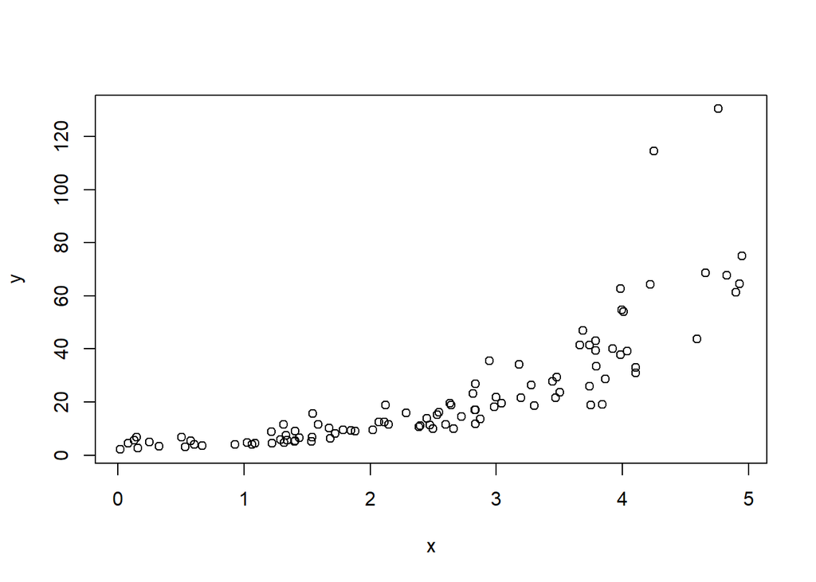

```r
set.seed(1234)
n = 100 ; beta0 = 1 ; beta1 = 0.7

e = rnorm(n, mean = 0, sd = sqrt(0.1))
x = runif(n, min = 0, max = 5)
y = exp(beta0 + beta1 * x + e)

mydata = data.frame(x = x, y = y)
plot(y ~ x, data = mydata)
```

$log(y)$가 단순회귀모형 $(\beta_0 = 1, \beta_1 =0.7)$의 관계를 갖는 것으로, $\lambda = 0$에서 $(x,y)$가 생성되었다. 5.1.3절에서 $\lambda$를 결정하는 방법을 소개한 것처럼 멱변환 후 $SSE_{\lambda}$를 계산하는 `SSE_lambda()`함수를 생성해 보았다.

```r
SSE_lambda = function(x, y, lambda){

  if (lambda == 0){
    z_lambda = log(y) * prod(y)^{1/n}
  }else{
    z_lambda = (y^{lambda} - 1) / lambda * prod(y)^{(-1/n) * (lambda - 1)}
  }

  n = length(y)
  X = matrix(c(rep(1, n), x), n, 2)
  H = X %*% solve(t(X) %*% X) %*% t(X)
  I = diag(1, n)

  SSE_lambda = t(z_lambda) %*% (I - H) %*% z_lambda
  return(SSE_lambda)
}
```

위에서 생성한 함수를 이용하여, 일련의 lambda($\lambda$) 값에 대하여 `SSE_lambda()`함수값을 벡터화하는 함수 `vec_SSE_lambda()`를 작성하면, `lambda`를 [-2, 2]까지 0.2씩 변화시켜가며 `SSE_lambda`를 최소로 하는 최적의 lambda($\lambda$)를 찾을 수 있다.

```r
vec_SSE_lambda <- Vectorize(SSE_lambda, "lambda")
lambda <- seq(-2, 2, 0.2)
all_SSE <- vec_SSE_lambda(mydata$x, mydata$y, lambda)
(best_lambda <- lambda[which.min(all_SSE)])
```

```
## [1] 0
```

```r
(min_SSE <- all_SSE[which.min(all_SSE)])
```

```
## [1] 2159.084
```

위 결과를 보면 lambda = 0 일때 `SSE_lambda = 2159.1`로 최소가 되는 것을 알 수 있다. lambda를 [-2, 2]까지 0.2씩 변화하면서 이에 대응하는 log(SSE_lambda)값을 그려보면 다음과 같다.

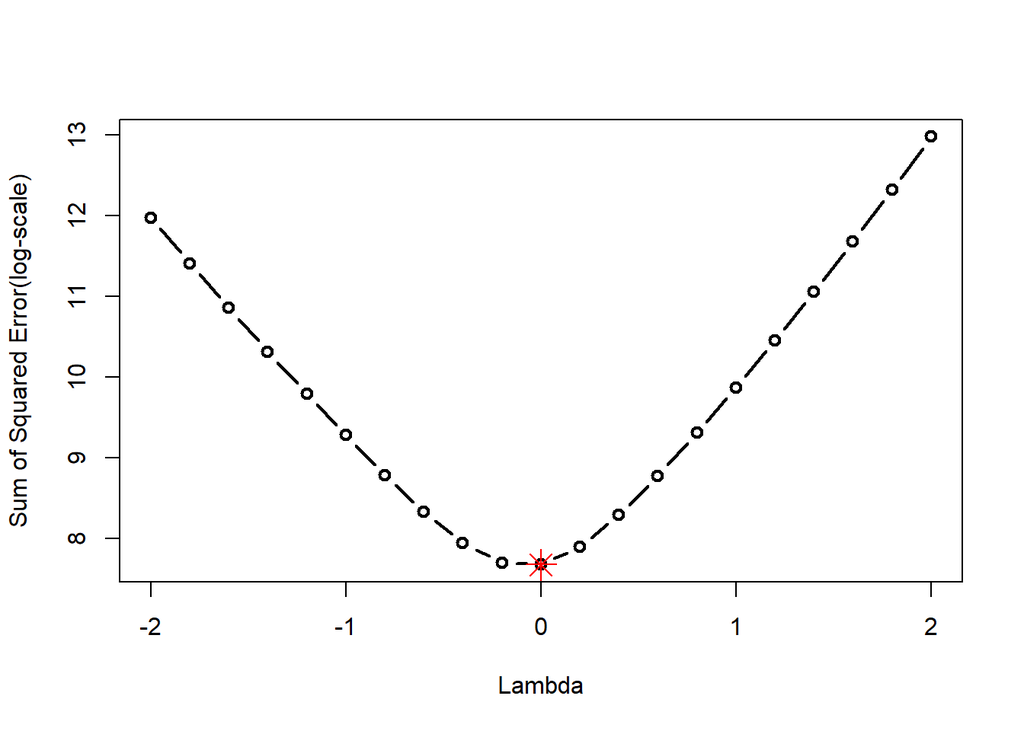

```r
plot(lambda, log(all_SSE),
     type = "b", lwd = 2,
     xlab = "Lambda", ylab = "Sum of Squared Error(log-scale)")

points(x = best_lambda, y = log(min_SSE),
       col = "red", cex = 2, pch = 8)
```

### 더 큰 데이터셋의 경우

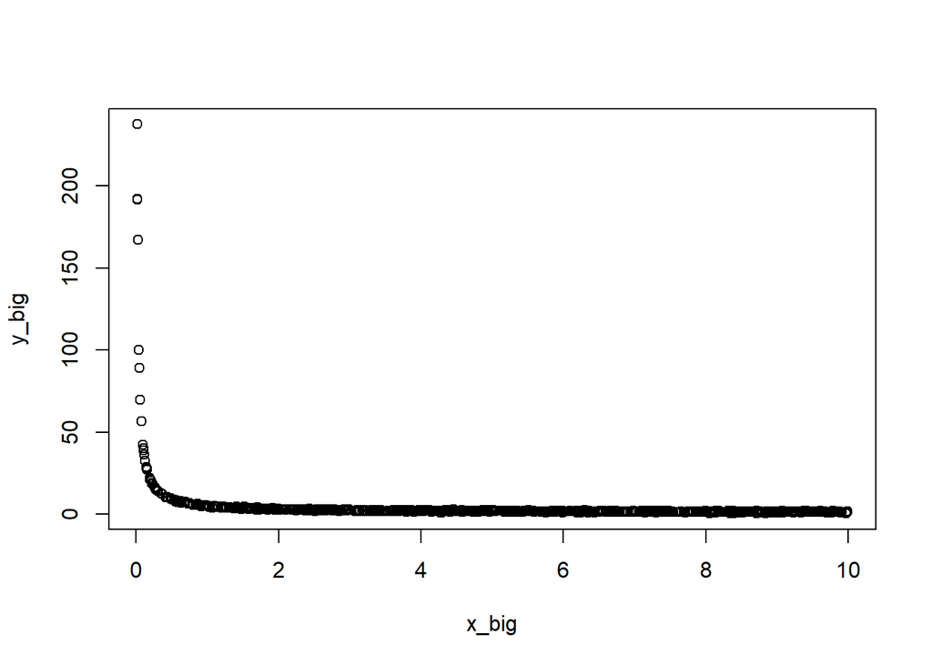

```r
set.seed(1234)
n = 1000 ; beta0_big = 1 ; beta1_big = 4

e_big = rnorm(n, mean = 0, sd = sqrt(0.1))
x_big = runif(n, min = 0, max = 10)
# y_big = 1 / (1 + exp(beta0_big + beta1_big * x_big + e_big))
y_big = beta0_big + beta1_big * (1/x_big) + e_big

mydata_big = data.frame(x = x_big, y = y_big)
plot(y_big ~ x_big, data = mydata_big)
```

```r
SSE_lambda_big = function(x, y, lambda){

  if (lambda == 0){
    z_lambda = log(y) * prod(y)^(1/n)
  }else{
    z_lambda = (y^{lambda} - 1) / lambda * prod(y)^{(-1/n) * (lambda - 1)}
  }

  n = length(y)
  X = matrix(c(rep(1, n), x), n, 2)
  H = X %*% solve(t(X) %*% X ) %*% t(X)
  I = diag(1, n)

  SSE_lambda = t(z_lambda) %*% (I - H) %*% z_lambda
  return(SSE_lambda)
}

vec_SSE_lambda_big <- Vectorize(SSE_lambda_big, "lambda")
lambda_big <- seq(-3, 3, 0.2)
all_SSE_big <- vec_SSE_lambda_big(mydata_big$x, mydata_big$y, lambda_big)
(best_lambda_big <- lambda_big[which.min(all_SSE_big)])
```

```
## [1] 1.2
```

```r
(min_SSE_big <- all_SSE_big[which.min(all_SSE_big)])
```

```
## [1] 0
```

[figure not shown]

```r
plot(lambda_big, log(all_SSE_big),
     type = "b", lwd = 2,
     xlab = "Lambda", ylab = "Sum of Squared Error(log-scale)")

points(x = best_lambda_big, y = log(min_SSE_big),
       col = "red", cex = 3, pch = 19)
```

## 연습문제

### 5.1

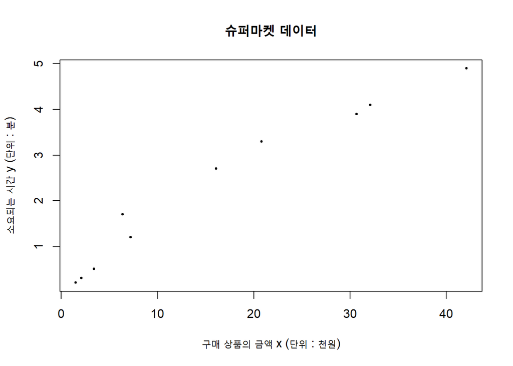

```r
x = c(6.4,16.1,42.1,2.1,30.7,32.1,7.2,3.4,20.8,1.5)
y = c(1.7,2.7,4.9,0.3,3.9,4.1,1.2,0.5,3.3,0.2)

plot(x, y, xlab = "구매 상품의 금액 x (단위 : 천원)", ylab = "소요되는 시간 y (단위 : 분)",
     main = "슈퍼마켓 데이터", pch = 19, cex = 0.4)
```

```r
library(glue)

S_xx = sum((x-mean(x))^{2}) ; S_xy = sum( (x-mean(x))*(y-mean(y)) ) ; S_yy = sum((y-mean(y))^{2})
beta1_hat = S_xy / S_xx ; beta0_hat = mean(y) - beta1_hat * mean(x)
y_hat = beta0_hat + beta1_hat * x

SST = S_yy ; SSE = sum((y-y_hat)^{2}) ; SSR = SST - SSE

## (2)
r_squared = SSR/SST ;
print(glue("r_squared = {r_squared}"))
```

```
## r_squared = 0.954247030991951
```

```r
print(glue("yhat = {beta0_hat} + {beta1_hat} x \n"))
```

```
## yhat = 0.396459710153422 + 0.115981544941292 x
```

```r
## (3)
r_sq_calc = function(x, y){
  xbar = mean(x) ; ybar = mean(y)
  S_xx = sum((x-xbar)^{2}) ; S_xy = sum((x-xbar)*(y-ybar) ) ; S_yy = sum((y-ybar)^{2})
  beta1_hat = S_xy / S_xx ; beta0_hat = ybar - beta1_hat * xbar
  y_hat = beta0_hat + beta1_hat * x

  SST = S_yy ; SSE = sum((y-y_hat)^{2}) ; SSR = SST - SSE
  r_squared = SSR/SST ; r_squared
  return(list(r_squared = r_squared, beta1_hat = beta1_hat, beta0_hat = beta0_hat))
}

## (3)
y_a = log(y) ; result_a = r_sq_calc(x, y_a) ; r_sq_a = result_a$r_squared
x_b = sqrt(x) ; result_b = r_sq_calc(x_b, y) ; r_sq_b = result_b$r_squared
x_c = log(x, base = 10) ; y_c = log(y, base = 10) ; result_c = r_sq_calc(x_c, y_c) ; r_sq_c = result_c$r_squared
y_d = log(y, base = 10) ; result_d = r_sq_calc(x, y_d) ; r_sq_d = result_d$r_squared
x_e = 1/x ; result_e = r_sq_calc(x_e, y) ; r_sq_e = result_e$r_squared

print(glue("(a) r squared = {r_sq_a}, (b) r squared = {r_sq_b}, (c) r squared = {r_sq_c},
            (d) r squared = {r_sq_d}, (e) r squared = {r_sq_e}"))
```

```
## (a) r squared = 0.738465758283742, (b) r squared = 0.988811022763704, (c) r squared = 0.962450181233903,
## (d) r squared = 0.738465758283742, (e) r squared = 0.687306669612189
```

```r
## (4)
beta0_hat = result_b$beta0_hat ; beta1_hat = result_b$beta1_hat
y_hat_10 = beta0_hat + beta1_hat * sqrt(10) ; y_hat_10
```

```
## [1] 1.885693
```

### 5.2

```
## y_hat = -313.749999999962 + 6.37214285714231 * x + -0.0213428571428553 * x^2
```

```
## r_squared = 0.88920504408171
```

```
## SSPE = 1310, SSLF = 1034.64285714286, SSE = 2344.64285714286
## Since F_0 <= F_0.05(4, 6), there is not enough evidence to reject the null hypothesis.
## Here, F_0 = 1.185 and F_0.05(4, 6) = 4.53367695027524
```

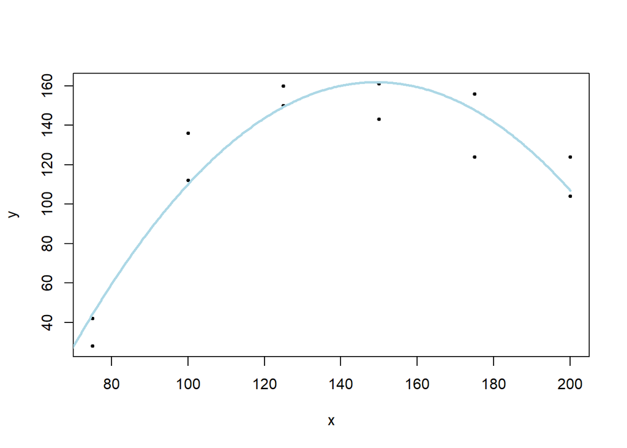

### 5.3

#### 5.3 - (1)

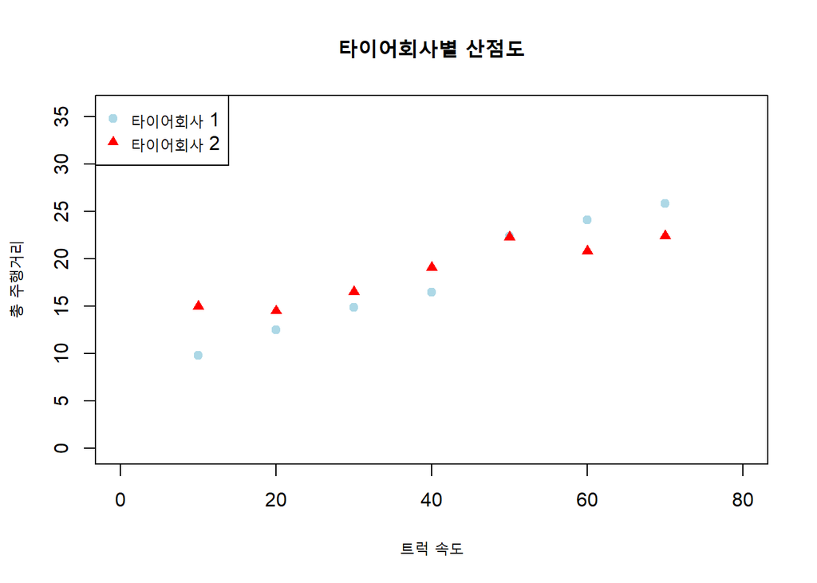

#### 5.3 - (2)

```
## y1_hat = 6.75714285714286 + 0.281071428571429x1
```

```
## y2_hat = 12.8571428571429 + 0.145x2
```

```
## y_hat = -33.9593822781875 + 4.03519622718092x
```

```
## SSE_1 = 5.55678571428571, SSE_2 = 8.50714285714285, df_R = 12, df_F = 10
```

```
## SSE_F = 14.0639285714286, SSE_R = 786.010900973163
```

```
## F_0 = 274.442154793781, F_alpha = 4.1028210151304
```

```
## |t_0| = 0.332500737276496, t_alpha/2(10) = 2.22813885198627
```

### 5.8

```
## SST = 3.72900000000004, SSR = 3.6125, SSE = 0.116500000000042
```

```
## F_0 = 248.068669527808, F_alpha = 5.31765507157871
```

```
## SSPE = 0.0949999999999998, SSLF = 0.0215000000000422
```

```
## F_0_LF = 0.377192982456882, F_alpha = 5.40945131805649
```

### 5.11

```
##     X Year  High   Low Time
## 1   1 1962 25.82 18.24 1960
## 2   2 1963 25.35 16.50 1960
## 3   3 1964 24.29 20.26 1960
## 4   4 1965 24.05 20.97 1960
## 5   5 1966 24.89 19.43 1960
## 6   6 1967 25.35 19.31 1960
## 7   7 1968 25.23 20.85 1960
## 8   8 1969 25.06 19.54 1960
## 9   9 1970 27.13 20.49 1970
## 10 10 1971 27.36 21.91 1970
## 11 11 1972 26.65 22.51 1970
## 12 12 1973 27.13 18.81 1970
## 13 13 1974 27.49 19.42 1970
## 14 14 1975 27.08 19.10 1970
## 15 15 1976 27.51 18.80 1970
## 16 16 1977 27.54 18.80 1970
## 17 17 1978 26.21 17.57 1970
```

#### 5.11 - (1)

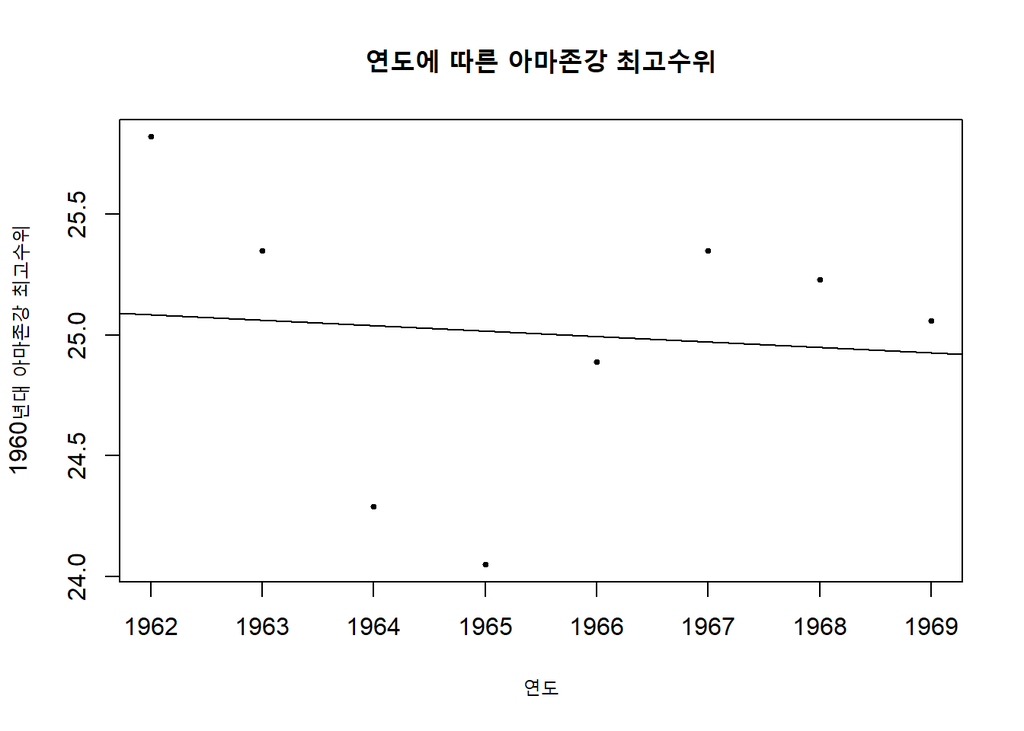

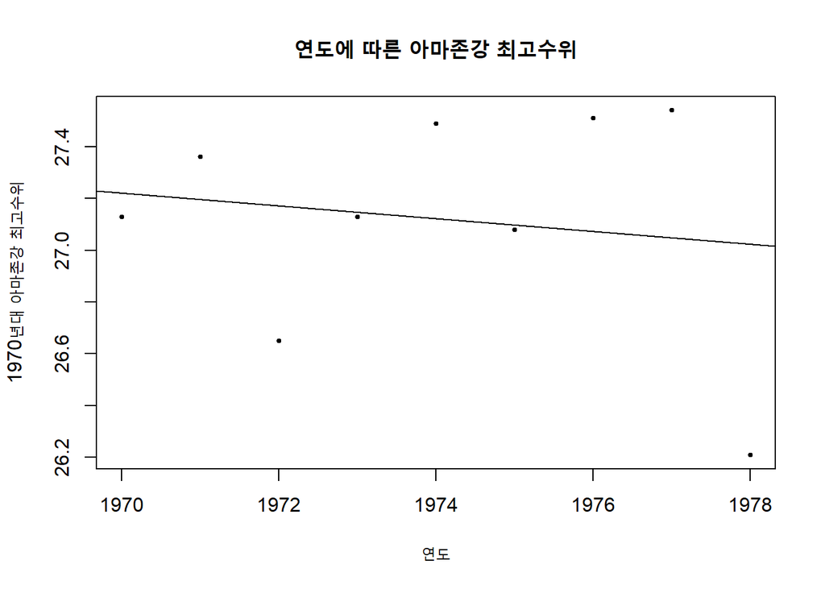

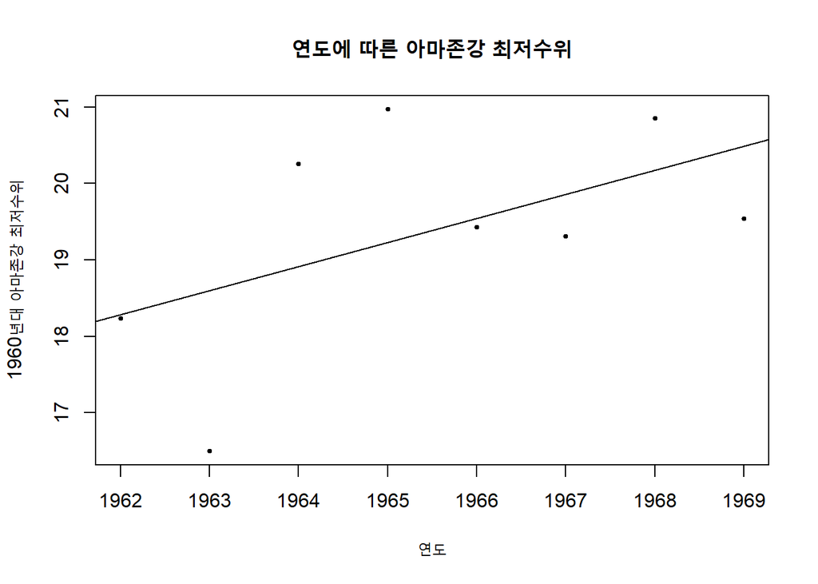

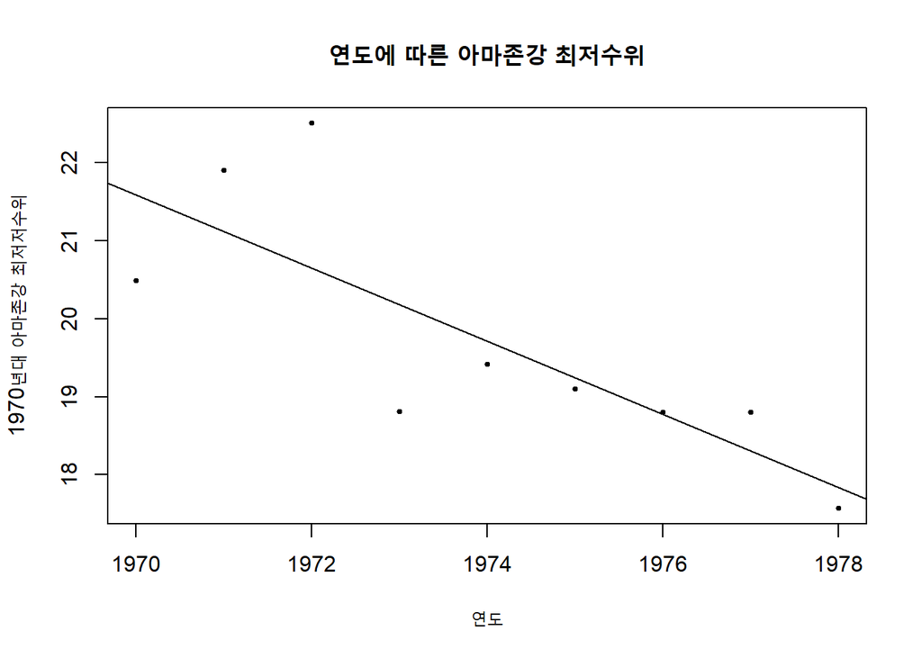

#### 5.11 - (2)

```r
library(glue)
## 최고수위의 경우
### 완전 모형 (full model)
anova_h_1960 = anova(lm_h_1960) ; anova_h_1970 = anova(lm_h_1970)
SSE_h_1960 = anova_h_1960$`Sum Sq`[2] ; SSE_h_1970 = anova_h_1970$`Sum Sq`[2]
df_h_1960 = anova_h_1960$Df[2] ; df_h_1970 = anova_h_1970$Df[2]

SSE_F_h = SSE_h_1960 + SSE_h_1970 ; df_F_h = df_h_1960 + df_h_1970

### 축소 모형 (reduced model)
y_h = c(y_h_1960, y_h_1970) ; x_h = c(x_1960, x_1970)
lm_h = lm(y_h ~ x_h)
anova_h = anova(lm_h)
SSE_R_h = anova_h$`Sum Sq`[2] ; df_R_h = anova_h$Df[2]

F_0 = ((SSE_R_h - SSE_F_h) / (df_R_h - df_F_h)) / (SSE_F_h / df_F_h)
F_alpha = qf(0.01, df_R_h - df_F_h, df_F_h, lower.tail = FALSE)

print(glue("F_0 = {F_0}, F_alpha = {F_alpha}"))
```

```
## F_0 = 9.46839637147935, F_alpha = 6.70096453588078
```

$F_0 = 9.468 > F_\alpha(df_R - df_F, df_F) = 6.701$ 이므로 귀무가설을 기각한다. 즉 1960년대와 1970년대의 아마존강 최고수위에 관한 회귀모형은 동일하다고 할 수 없다.

```r
library(glue)
## 최저수위의 경우
### 완전 모형 (full model)
anova_l_1960 = anova(lm_l_1960) ; anova_l_1970 = anova(lm_l_1970)
SSE_l_1960 = anova_l_1960$`Sum Sq`[2] ; SSE_l_1970 = anova_l_1970$`Sum Sq`[2]
df_l_1960 = anova_l_1960$Df[2] ; df_l_1970 = anova_l_1970$Df[2]

SSE_F_l = SSE_l_1960 + SSE_l_1970 ; df_F_l = df_l_1960 + df_l_1970

### 축소 모형 (reduced model)
y_l = c(y_l_1960, y_l_1970) ; x_l = c(x_1960, x_1970)
lm_l = lm(y_l ~ x_l)
anova_l = anova(lm_l)
SSE_R_l = anova_l$`Sum Sq`[2] ; df_R_l = anova_l$Df[2]

F_0_l = ((SSE_R_l - SSE_F_l) / (df_R_l - df_F_l)) / (SSE_F_l / df_F_l)
F_alpha_l = qf(0.01, df_R_l - df_F_l, df_F_l, lower.tail = FALSE)

print(glue("F_0 = {F_0_l}, F_alpha = {F_alpha_l}"))
```

```
## F_0 = 6.24410676428248, F_alpha = 6.70096453588078
```

$F_0 = 6.244 < F_\alpha(df_R - df_F, df_F) = 6.701$ 이므로 귀무가설을 기각할 수 없없다. 즉 1960년대와 1970년대의 아마존강 최저수위에 관한 회귀모형은 동일하다고 할 수 있다.

#### 5.11 - (3)

```r
S_xx1 = sum((x_1960 - mean(x_1960))^2) ; S_xx2 = sum((x_1970 - mean(x_1970))^2)

## 최고수위의 경우
beta11_hat_h = lm_h_1960$coefficients[2]; beta12_hat_h = lm_h_1970$coefficients[2]
var_hat_h = (SSE_F_h/df_F_h) * (1/S_xx1 + 1/S_xx2)

t_0 = (beta11_hat_h - beta12_hat_h) / sqrt(var_hat_h) ; t_alpha = qt(0.005, df_F_h, lower.tail = FALSE)

print(glue("유의수준 alpha = 0.01, 아마존강 최고수위의 경우 t_0 = {t_0}, t_alpha = {t_alpha}"))
```

```
## 유의수준 alpha = 0.01, 아마존강 최고수위의 경우 t_0 = 0.0170504612965581, t_alpha = 3.01227583871658
```

```r
## 최고수위의 경우
beta11_hat_l = lm_l_1960$coefficients[2]; beta12_hat_l = lm_l_1970$coefficients[2]
var_hat_l = (SSE_F_l/df_F_l) * (1/S_xx1 + 1/S_xx2)

t_0 = (beta11_hat_l - beta12_hat_l) / sqrt(var_hat_l) ; t_alpha = qt(0.005, df_F_l, lower.tail = FALSE)

print(glue("유의수준 alpha = 0.01, 아마존강 최저수위의 경우 t_0 = {t_0}, t_alpha = {t_alpha}"))
```

```
## 유의수준 alpha = 0.01, 아마존강 최저수위의 경우 t_0 = 3.26530513772471, t_alpha = 3.01227583871658
```

아마존강 최고수위의 경우 $|t_0| = 0.017 < t_\alpha(df_F) = 3.0122$으로, 귀무가설을 기각할 수 없다. 즉 유의수준 $\alpha = 0.01$에서 1960년대의 최고수위 증가량 수준과 1970년대의 최고수위 증가량 수준은 동일하다고 할 수 있다.

아마존강 최저수위의 경우 $|t_0| = 3.265 > t_\alpha(df_F) = 3.0122$으로, 귀무가설을 기각한다. 즉 유의수준 $\alpha = 0.01$에서 1960년대의 최저수위 증가량 수준과 1970년대의 최고수위 증가량 수준은 동일하다고 할 수 없다.